# 📘 **Guía para la Generación de Gráficas Académicas con ChatGPT, Matplotlib y LaTeX**

### **Aplicaciones en Integración Numérica, ABP**

### 👨‍🏫 **Autores:**

**Carlos Andrés Tamayo Benjumea**  
Ingeniero de Sistemas | Docente Universitario  
**José Javier Coronel Casadiego**  
Ingeniero de Sistemas | Especialista en Docencia Universitaria | Docente Universitario

### 🛠️ **Herramientas Utilizadas:**

- ChatGPT
- Google Colab
- Matplotlib
- LaTeX

### 🎯 **Propósito:**

Demostrar cómo utilizar inteligencia artificial generativa y herramientas computacionales para automatizar la construcción de recursos visuales educativos en matemáticas, ingeniería y ciencias aplicadas.

### 📅 **Fecha:**

17 de Julio de 2025

## 🎓 Importancia de ChatGPT, Matplotlib y LaTeX en Investigación y Docencia

El uso de herramientas tecnológicas como **ChatGPT, Matplotlib y LaTeX** está transformando la forma en que los estudiantes, docentes e investigadores abordan la generación de recursos educativos y científicos. Estas tecnologías no solo permiten automatizar tareas repetitivas, sino que además facilitan la creación de contenido visual y matemático con altos estándares de calidad, lo cual es fundamental en áreas como la **ingeniería, las ciencias básicas, la inteligencia artificial y la educación STEM** (Hunter, 2007; Lamport, 1994; Kasneci et al., 2023).

En el ámbito académico, **LaTeX** es reconocido como un estándar para la redacción de documentos que contienen fórmulas matemáticas complejas, garantizando una presentación profesional y precisa (Lamport, 1994). Por su parte, **Matplotlib** se ha consolidado como una de las bibliotecas más poderosas y flexibles para la visualización de datos y la representación gráfica de funciones matemáticas en **Python**, permitiendo crear desde gráficos sencillos hasta visualizaciones complejas con propósitos académicos o investigativos (Hunter, 2007).

Finalmente, **ChatGPT** representa una nueva era de interacción con la inteligencia artificial, brindando asistencia en la redacción de código, generación de explicaciones, formulación de ejercicios y producción de material educativo personalizado (OpenAI, 2023). Su integración en el proceso de enseñanza-aprendizaje aporta eficiencia y creatividad, fortaleciendo las competencias digitales de estudiantes y profesores (Kasneci et al., 2023).

Esta guía propone un enfoque práctico para aprovechar estas tres herramientas de manera articulada, con el propósito de fortalecer las competencias en la **generación de recursos visuales para matemáticas, ingeniería y análisis de datos**, con aplicaciones en **análisis numérico**.

## 📝 Justificación Pedagógica

En el contexto actual de la educación superior, se hace necesario promover estrategias que integren el uso de tecnologías emergentes para fortalecer las competencias digitales, científicas y comunicativas de los estudiantes. La combinación de herramientas como **ChatGPT, Matplotlib y LaTeX** permite generar entornos de aprendizaje más dinámicos, productivos y alineados con las demandas del siglo XXI (Siemens, 2005; OECD, 2021).

La inteligencia artificial, representada aquí por **ChatGPT**, ofrece nuevas posibilidades para la enseñanza y el aprendizaje al facilitar la generación de código, la resolución guiada de problemas y la construcción de ejemplos claros y didácticos (Holmes et al., 2022). Esta asistencia resulta especialmente valiosa para estudiantes que inician su formación en áreas como **matemáticas aplicadas, ingeniería, ciencias de datos e inteligencia artificial**.

Por su parte, **Matplotlib** posibilita la representación visual de fenómenos matemáticos y científicos, lo cual es fundamental para mejorar la comprensión de conceptos abstractos, facilitar la comunicación de resultados y promover el pensamiento crítico a través del análisis gráfico (Perez & Granger, 2007). Asimismo, **LaTeX** fortalece las competencias en la redacción técnica, brindando herramientas para expresar ideas matemáticas de manera precisa, clara y profesional (Knuth, 1984).

El presente material está alineado con metodologías activas de aprendizaje, como el **Aprendizaje Basado en Problemas (ABP)** y el **aprendizaje por proyectos**, permitiendo a los estudiantes aplicar sus conocimientos de programación, matemáticas y comunicación visual en la solución de problemas reales (Barrows, 1996). Además, responde a las necesidades actuales de la academia de incorporar prácticas que articulen **ciencia, tecnología, ingeniería y matemáticas (STEM)** para favorecer el desarrollo de competencias transversales (OECD, 2021).

## 🖥️ ¿Qué es Google Colab?

**Google Colab** (abreviatura de *Google Colaboratory*) es una plataforma gratuita basada en la nube que permite a los usuarios escribir y ejecutar código en **Python** directamente desde un navegador web, sin necesidad de instalaciones locales. Ofrece un entorno muy similar a **Jupyter Notebook**, pero con la ventaja de integrar almacenamiento en **Google Drive** y acceso a recursos computacionales avanzados, como **GPU y TPU**, lo que facilita el desarrollo de proyectos que requieren procesamiento intensivo.

### 📌 Principales características:

- Permite la ejecución de código Python en la nube.
- Facilita la enseñanza y el aprendizaje de programación, ciencia de datos, inteligencia artificial, entre otros campos.
- Permite integrar texto con formato **Markdown** y ecuaciones **LaTeX** para crear documentos académicos interactivos.
- Es ampliamente utilizado para proyectos colaborativos y para compartir notebooks fácilmente a través de enlaces.

Gracias a su entorno accesible, intuitivo y gratuito, **Google Colab** se ha convertido en una herramienta esencial para estudiantes, docentes e investigadores que trabajan con Python, especialmente en áreas relacionadas con **ciencia de datos, inteligencia artificial y visualización de datos**.

# 🤖 ¿Cómo utilizar ChatGPT para generar gráficos en Matplotlib?

## ✅¿Qué es ChatGPT?

**ChatGPT** es una inteligencia artificial desarrollada por OpenAI que puede entender y generar lenguaje natural.  
Una de sus funciones más útiles para estudiantes y profesionales es **escribir código automáticamente** y explicar su funcionamiento.

También puede generar:

- Fórmulas matemáticas en **LaTeX**.
- Código de **Python**, incluyendo librerías como **Matplotlib**, **Numpy** y muchas más.
- Ejemplos, ejercicios y explicaciones claras.

## 🎯 Cómo solicitar a ChatGPT un código de Matplotlib

Podemos pedirle a ChatGPT algo como:

> "Genera un código en Python usando Matplotlib para graficar la función ( y = x^2 ) en el intervalo [0, 10]. Agrega título, etiquetas y leyenda."

ChatGPT nos entregará un código muy similar a este:

## 🐍 Código generado por ChatGPT

```
import numpy as np
import matplotlib.pyplot as plt

# Datos
x = np.linspace(0, 10, 100)
y = x**2

# Crear la gráfica
plt.plot(x, y, label=r'$y = x^2$', color='blue')

# Personalizar
plt.title('Gráfica de $y = x^2$')
plt.xlabel('x')
plt.ylabel('y')
plt.legend()
plt.grid(True)

# Mostrar
plt.show()
```

[output not shown]

## 📝 Cómo Formular Prompts para la Generación Automática de Gráficas

Un buen prompt debe incluir:

- Qué función deseas graficar (expresa la ecuación clara y en LaTeX).
- Rango de valores para `x`.
- Si deseas sombrear un área.
- Si deseas líneas verticales en incrementos definidos.
- Si quieres flechas en los ejes.
- Si quieres etiquetas matemáticas en LaTeX.

**Ejemplo de Prompt para ChatGPT:**

> "Genera código Python usando Matplotlib para graficar ( f(x) = \frac{1}{\sqrt{x^2 + 4}} ) desde 0 hasta 2.5, con área sombreada de 0 a 2, líneas verticales cada 0.25, flechas en los ejes, y etiquetas en LaTeX."

# Importancia de LaTeX en la Documentación Académica

## 🎯 ¿Qué es LaTeX?

LaTeX es un lenguaje de marcado ampliamente usado para escribir documentos científicos y matemáticos.  
En **Google Colab** puedes escribir fórmulas matemáticas usando Markdown o directamente desde Python.

### Opciones:

- `$ ... $` para matemáticas **en línea**
- `$$ ... $$` para fórmulas **centradas**

## ➕ Funciones matemáticas básicas en LaTeX

| Propósito | Código LaTeX | Visualización |
| --- | --- | --- |
| Función lineal | `$f(x) = 2x + 1$` | $ f(x) = 2x + 1 $ |
| Cuadrática | `$f(x) = x^2 + 3x + 2$` | $f(x) = x^2 + 3x + 2$ |
| Fracción | `$\frac{a}{b}$` | $ \frac{a}{b} $ |
| Raíz cuadrada | `$\sqrt{x}$` | $ \sqrt{x} $ |
| Integral definida | `$\int_0^1 x^2 dx$` | $ \int_0^1 x^2 dx $ |

## 📌 Ejemplo en Markdown: Función cuadrática

La función cuadrática se escribe así:

$$ f(x) = x^2 + 3x + 2 $$

## ✨ Recomendaciones para mejorar presentación

Usa `\text{}` para mezclar texto y matemáticas:

$$ \text{Si } f(x) = x^2, \text{ entonces } f(2) = 4 $$

Paréntesis grandes: `\left( ... \right)`

$$ f(x) = \left( x + 1 \right)^2 $$

# 🎨 Introducción a Matplotlib para la Educación

## 📊 ¿Qué es Matplotlib?

**Matplotlib** es una biblioteca de Python que permite crear gráficos y visualizaciones de datos de forma sencilla y profesional.

Es muy utilizada en ciencia de datos, ingeniería, matemáticas, inteligencia artificial y cualquier disciplina que necesite mostrar datos de forma gráfica.

## Primer gráfico básico

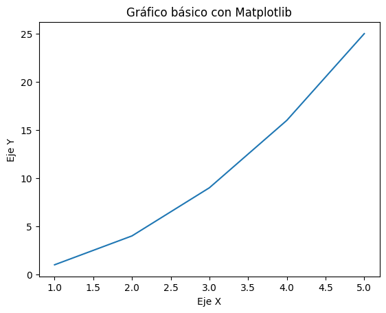

```python
import matplotlib.pyplot as plt

# Datos simples
x = [1, 2, 3, 4, 5]
y = [1, 4, 9, 16, 25]

# Crear gráfico
plt.plot(x, y)

# Título y etiquetas
plt.title('Gráfico básico con Matplotlib')
plt.xlabel('Eje X')
plt.ylabel('Eje Y')

# Mostrar
plt.show()
```

## ✨ Personalización básica de gráficos

Puedes añadir color, estilo de línea, y marcadores.  
Aquí algunos ejemplos rápidos:

```
plt.plot(x, y, color='red', linestyle='--', marker='o')
```

## 🐍 **Gráfico personalizado**

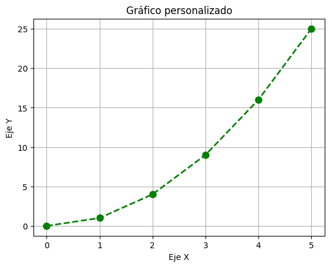

```python
# Datos
x = [0, 1, 2, 3, 4, 5]
y = [0, 1, 4, 9, 16, 25]

# Gráfico personalizado
plt.plot(x, y, color='green', linestyle='--', linewidth=2, marker='o', markersize=8)

plt.title('Gráfico personalizado')
plt.xlabel('Eje X')
plt.ylabel('Eje Y')

plt.grid(True)
plt.show()
```

## 📂 Otros tipos de gráficos útiles

- `plt.scatter()`: Gráfico de puntos
- `plt.bar()`: Barras verticales
- `plt.hist()`: Histograma
- `plt.pie()`: Gráfico de pastel (tarta)

Ejemplo rápido de barras:

```
x = ['A', 'B', 'C']
y = [3, 7, 5]
plt.bar(x, y)
plt.title('Gráfico de barras')
plt.show()
```

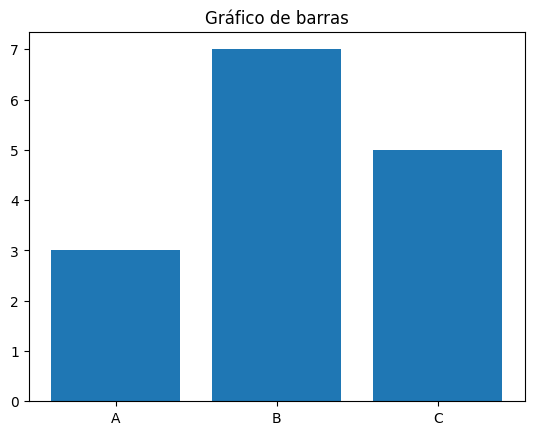

```python
x = ['A', 'B', 'C']
y = [3, 7, 5]
plt.bar(x, y)
plt.title('Gráfico de barras')
plt.show()
```

```python
# En Google Colab, normalmente no hace falta instalar estas
import numpy as np
import matplotlib.pyplot as plt
import os
```

```python
# Crear carpeta para guardar imágenes organizadamente
folder = "graficas_libro"
if not os.path.exists(folder):
    os.mkdir(folder)
```

# 📊 Ejercicio: Área Bajo la Curva $ f(x) = \cos(x) $

En este ejercicio se busca representar gráficamente el **área bajo la curva** de la función: $$ f(x) = \cos(x) $$ en el intervalo de $x = 0$ a $x = \frac{\pi}{2}$, incluyendo:

### 📝 Prompt utilizado en ChatGPT para generar el código de este ejercicio:

> "Genera código en Python usando Matplotlib para graficar la función coseno desde 0 hasta pi, con área sombreada en rojo desde 0 hasta pi/2, incluyendo líneas verticales en incrementos de pi/8, flechas en los ejes para simular coordenadas prolongadas y etiquetas en LaTeX."

Este prompt fue formulado para obtener un código limpio, claro y adecuado para materiales educativos de análisis numérico.

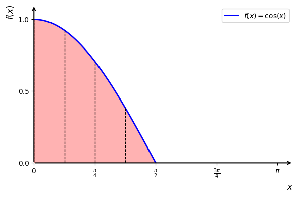

```python
import numpy as np
import matplotlib.pyplot as plt

# Datos para la curva completa
x = np.linspace(0, np.pi, 300)
y = np.cos(x)

fig, ax = plt.subplots(figsize=(6, 4))

# Curva completa
ax.plot(x, y, color='blue', linewidth=2, label=r'$f(x) = \cos(x)$')

# Área sombreada de 0 a pi/2
x_fill = np.linspace(0, np.pi/2, 200)
y_fill = np.cos(x_fill)
ax.fill_between(x_fill, y_fill, color='red', alpha=0.3)

# Líneas verticales en incrementos de pi/8
x_points = np.arange(0, np.pi/2 + 0.01, np.pi/8)
for x0 in x_points:
    y0 = np.cos(x0)
    ax.plot([x0, x0], [0, y0], linestyle='--', color='black', linewidth=1)

# Flechas para ejes personalizados
xmax, ymax = np.pi + 0.2, 1.1
ax.annotate('', xy=(xmax, 0), xytext=(0, 0),
            arrowprops=dict(arrowstyle='->', linewidth=1.5, color='black'))
ax.annotate('', xy=(0, ymax), xytext=(0, 0),
            arrowprops=dict(arrowstyle='->', linewidth=1.5, color='black'))

# Configuración de etiquetas
ax.set_xticks([0, np.pi/4, np.pi/2, 3*np.pi/4, np.pi])
ax.set_xticklabels([r'$0$', r'$\frac{\pi}{4}$', r'$\frac{\pi}{2}$', r'$\frac{3\pi}{4}$', r'$\pi$'])
ax.set_yticks([0, 0.5, 1])

ax.set_xlabel(r'$x$', fontsize=12, loc='right')
ax.set_ylabel(r'$f(x)$', fontsize=12, loc='top')

ax.set_xlim(0, xmax)
ax.set_ylim(0, ymax)
ax.grid(False)

# Eliminar todos los spines (bordes del recuadro)
for spine in ['top', 'right', 'left', 'bottom']:
    ax.spines[spine].set_visible(False)

plt.legend()

# Guardar sin márgenes al exportar
#plt.savefig('coseno_area_sombreada.png', dpi=300, bbox_inches='tight', transparent=True)

plt.tight_layout()
plt.show()
```

## 📊 Ejercicio: Representación Gráfica del Área Bajo la Curva $ f(x) = \frac{1}{\sqrt{x^2 + 4}} $

Este ejercicio tiene como propósito representar gráficamente el área bajo la curva de la función $$f(x) = \frac{1}{\sqrt{x^2 + 4}}$$ en el intervalo de $x = 0$ a $x = 2$, incluyendo:

- El área sombreada en rojo.
- Líneas verticales en incrementos de $0.25$.
- La curva completa hasta $x = 2.5$.
- Flechas en ambos ejes para representar prolongación de los ejes coordenados.
- Etiquetas matemáticas utilizando notación **LaTeX**.

### 📝 Prompt utilizado en ChatGPT para generar el código de este ejercicio:

> "Genera código Python usando Matplotlib para graficar la función f(x) = \frac{1}{\sqrt{x^2 + 4}} desde 0 hasta 2.5 , con área sombreada en rojo desde 0 hasta 2, incluyendo líneas verticales en incrementos de 0.25 , flechas en los ejes para simular los ejes coordenados prolongados, y etiquetas matemáticas en LaTeX."

Este prompt fue formulado para obtener un código limpio, claro y adecuado para materiales educativos de análisis numérico.

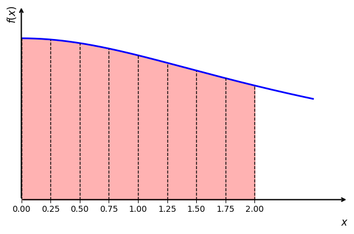

```python
import numpy as np
import matplotlib.pyplot as plt
import os

# Datos para la curva completa
x = np.linspace(0, 2.5, 300)
y = 1 / np.sqrt(x**2 + 4)

fig, ax = plt.subplots(figsize=(6, 4))

# Curva completa
ax.plot(x, y, color='blue', linewidth=2, label=r'$f(x) = \frac{1}{\sqrt{x^2 + 4}}$')

# Área sombreada de 0 a 2
x_fill = np.linspace(0, 2, 300)
y_fill = 1 / np.sqrt(x_fill**2 + 4)
ax.fill_between(x_fill, y_fill, color='red', alpha=0.3)

# Líneas verticales en incrementos de 0.25
x_points = np.arange(0, 2.01, 0.25)
for x0 in x_points:
    y0 = 1 / np.sqrt(x0**2 + 4)
    ax.plot([x0, x0], [0, y0], linestyle='--', color='black', linewidth=1)

# Ejes personalizados con flechas
xmax, ymax = 2.8, 0.6
ax.annotate('', xy=(xmax, 0), xytext=(0, 0),
            arrowprops=dict(arrowstyle='->', linewidth=1.5, color='black'))
ax.annotate('', xy=(0, ymax), xytext=(0, 0),
            arrowprops=dict(arrowstyle='->', linewidth=1.5, color='black'))

# Configuración de etiquetas
ax.set_xticks(np.arange(0, 2.01, 0.25))
ax.set_yticks([])

ax.set_xlabel(r'$x$', fontsize=12, loc='right')
ax.set_ylabel(r'$f(x)$', fontsize=12, loc='top')
ax.set_xlim(0, xmax)
ax.set_ylim(0, ymax)
ax.grid(False)

# ✅ Eliminar el cuadro exterior (spines)
for spine in ['top', 'right', 'left', 'bottom']:
    ax.spines[spine].set_visible(False)

plt.tight_layout()
plt.show()
```

## ✍️ Cómo usar LaTeX para Etiquetas en Matplotlib

Matplotlib permite escribir notación matemática de forma profesional usando `r'$ ... $'`

**Ejemplos:**

```
plt.xlabel(r'$x$')
plt.ylabel(r'$f(x) = \frac{1}{\sqrt{x^2 + 4}}$')
```

# Ejemplos de gráficas usadas en el libro

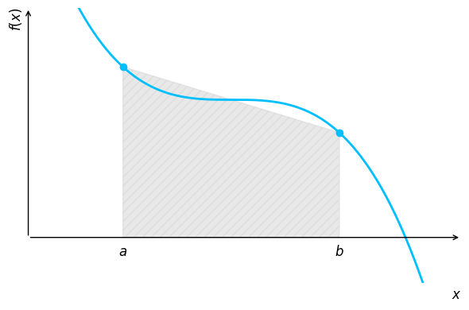

```python
# Función ajustada para un cambio más brusco en la mitad
x = np.linspace(0, 3, 500)
y = -0.7 * (x - 1.5)**3 + 1.5  # Aumenté el coeficiente y bajé la altura para hacerlo más visible

# Definir puntos a y b
a, b = 0.7, 2.3
x_fill = np.array([a, b])
y_fill = -0.7 * (x_fill - 1.5)**3 + 1.5

# Crear la figura
fig, ax = plt.subplots(figsize=(6, 4))
fig.patch.set_facecolor('white')

# Área sombreada estilo trapecio
ax.fill_between([a, b], [y_fill[0], y_fill[1]], color='lightgrey', alpha=0.5, hatch='///')

# Curva completa
ax.plot(x, y, color='deepskyblue', linewidth=2)

# Puntos a y b destacados
ax.scatter([a, b], y_fill, color='deepskyblue', zorder=5)

# Eliminar bordes (spines)
for spine in ['top', 'right', 'bottom', 'left']:
    ax.spines[spine].set_visible(False)

# Ejes con flechas
ax.annotate('', xy=(3.2, 0), xytext=(0, 0),
            arrowprops=dict(arrowstyle='->', color='black'))
ax.annotate('', xy=(0, 2.5), xytext=(0, 0),
            arrowprops=dict(arrowstyle='->', color='black'))

# Etiquetas a y b
ax.text(a, -0.2, r'$a$', ha='center', fontsize=12)
ax.text(b, -0.2, r'$b$', ha='center', fontsize=12)

# Etiquetas de ejes
ax.set_xlabel(r'$x$', fontsize=12, loc='right')
ax.set_ylabel(r'$f(x)$', fontsize=12, loc='top')

# Límites y limpieza
ax.set_xlim(0, 3.2)
ax.set_ylim(-0.5, 2.5)
ax.set_xticks([])
ax.set_yticks([])
ax.set_facecolor('white')
ax.grid(False)

plt.tight_layout()
plt.show()
```

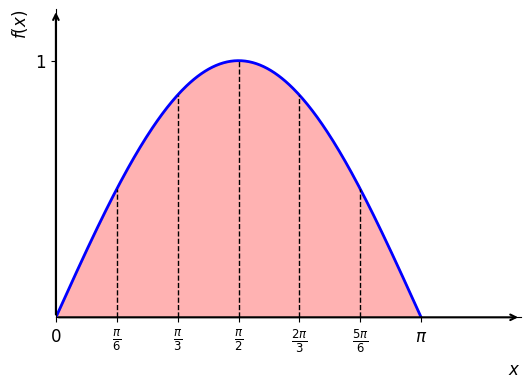

```python
# Datos para la función sin(x) entre 0 y pi
x = np.linspace(0, np.pi, 300)
y = np.sin(x)

# Crear la figura y ejes
fig, ax = plt.subplots(figsize=(6, 4))

# Graficar la curva sin(x)
ax.plot(x, y, color='blue', linewidth=2, label=r'$f(x) = \sin(x)$')

# Sombrear el área bajo la curva entre 0 y pi
ax.fill_between(x, y, color='red', alpha=0.3)

# Líneas verticales en x = 0, pi/6, pi/3, ..., pi
x_points = np.arange(0, np.pi + 0.01, np.pi / 6)
for x0 in x_points:
    ax.plot([x0, x0], [0, np.sin(x0)], linestyle='--', color='black', linewidth=1)

# Eliminar bordes superiores y derechos
ax.spines['top'].set_color('none')
ax.spines['right'].set_color('none')

# Posicionar ejes en el origen
ax.spines['left'].set_position('zero')
ax.spines['bottom'].set_position('zero')

# Añadir flechas a los ejes
xmax, ymax = 4, 1.2
ax.annotate('', xy=(xmax, 0), xytext=(0, 0),
            arrowprops=dict(arrowstyle='->', linewidth=1.5, color='black'))
ax.annotate('', xy=(0, ymax), xytext=(0, 0),
            arrowprops=dict(arrowstyle='->', linewidth=1.5, color='black'))

# Configurar xticks con fracciones de pi en pasos de pi/6
xticks = [0, np.pi/6, np.pi/3, np.pi/2, 2*np.pi/3, 5*np.pi/6, np.pi]
xticklabels = [r'$0$', r'$\frac{\pi}{6}$', r'$\frac{\pi}{3}$', r'$\frac{\pi}{2}$',
               r'$\frac{2\pi}{3}$', r'$\frac{5\pi}{6}$', r'$\pi$']
ax.set_xticks(xticks)
ax.set_xticklabels(xticklabels)

# Configurar yticks
ax.set_yticks([1])

# Cambiar el tamaño de los ticks
ax.tick_params(axis='both', which='both', labelsize=12)  # Cambia el número a lo que necesites

# Etiquetas y límites
ax.set_xlabel(r'$x$', fontsize=12, loc='right')
ax.set_ylabel(r'$f(x)$', fontsize=12, loc='top')
ax.set_xlim([0, xmax])
ax.set_ylim([0, ymax])

# Quitar cuadrícula
ax.grid(False)

# Mostrar la figura
plt.show()
```

## 💾 ¿Cómo guardar una imagen `.png` en Matplotlib dentro de una carpeta?

Cuando generamos una gráfica en **Matplotlib**, podemos guardar la imagen dentro de una carpeta específica para organizar mejor nuestros archivos.

### 📌 Pasos:

1️⃣ Crea la carpeta (si no existe) utilizando Python.  
2️⃣ Guarda la imagen dentro de esa carpeta con la función `plt.savefig()`.

### 🐍 **Ejemplo completo: Guardar en una carpeta llamada `imagenes`**

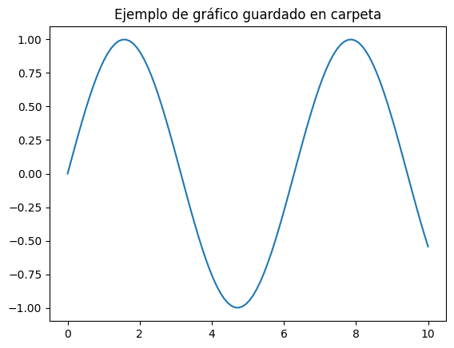

```python
import os
import numpy as np
import matplotlib.pyplot as plt

# Crear carpeta 'imagenes' si no existe
folder = 'imagenes'
os.makedirs(folder, exist_ok=True)

# Datos para la gráfica
x = np.linspace(0, 10, 100)
y = np.sin(x)

# Crear la gráfica
plt.plot(x, y)
plt.title('Ejemplo de gráfico guardado en carpeta')

# Definir la ruta completa del archivo
filename = os.path.join(folder, 'grafico_seno.png')

# Guardar la imagen como archivo .png dentro de la carpeta
plt.savefig(filename, dpi=300, bbox_inches='tight')

# Mostrar la gráfica
plt.show()
```

### 📂 ¿Dónde se guarda el archivo?

El archivo **se guarda dentro de la carpeta `imagenes` que se crea en el mismo directorio donde ejecutas tu código**.  
En **Google Colab**, esta carpeta aparecerá en el **explorador de archivos que se encuentra en la parte izquierda de la pantalla**.  
Desde allí podrás visualizarla, abrirla o descargar los archivos generados directamente.

## 📌 Conclusiones Finales

La combinación de **ChatGPT, Matplotlib y LaTeX** representa una estrategia pedagógica innovadora y efectiva para fortalecer las competencias en programación, matemáticas y comunicación científica en contextos educativos. Estas herramientas no solo permiten optimizar el tiempo de creación de materiales didácticos, sino que también promueven la autonomía del estudiante y su capacidad para resolver problemas mediante el uso de tecnología.

A través de esta guía, se ha demostrado cómo es posible automatizar la generación de recursos académicos de alta calidad, tales como gráficos matemáticos, representaciones de áreas bajo la curva y fórmulas en notación profesional, aplicando buenas prácticas de visualización y escritura técnica.

Además, la integración de estas herramientas en el aula contribuye al desarrollo de habilidades alineadas con las necesidades del siglo XXI, tales como el pensamiento computacional, la alfabetización en datos, el manejo de lenguajes de programación y la comunicación clara de ideas matemáticas.

Finalmente, se evidencia que el uso responsable e intencionado de la inteligencia artificial en entornos educativos no busca reemplazar el conocimiento humano, sino potenciarlo, facilitando procesos de enseñanza-aprendizaje más creativos, dinámicos y eficaces.

## 📚 Referencias

Barrows, H. S. (1996). *Problem-based learning in medicine and beyond: A brief overview*. *New Directions for Teaching and Learning, (68)*, 3-12. https://doi.org/10.1002/tl.37219966804

Holmes, W., Bialik, M., & Fadel, C. (2022). *Artificial Intelligence in Education: Promises and Implications for Teaching and Learning*. Center for Curriculum Redesign.

Hunter, J. D. (2007). *Matplotlib: A 2D graphics environment*. *Computing in Science & Engineering, 9*(3), 90–95. https://doi.org/10.1109/MCSE.2007.55

Kasneci, E., Sessler, K., Betsch, T., & Kasneci, G. (2023). *ChatGPT for Good? On Opportunities and Challenges of Large Language Models for Education*. *Learning and Individual Differences, 103*, 102274. https://doi.org/10.1016/j.lindif.2023.102274

Knuth, D. E. (1984). *The TeXbook*. Addison-Wesley.

Lamport, L. (1994). *LaTeX: A Document Preparation System* (2nd ed.). Addison-Wesley.

OECD. (2021). *AI and the Future of Skills, Volume 1: Capabilities and Assessments*. Organisation for Economic Co-operation and Development. https://doi.org/10.1787/5ee6c36f-en

OpenAI. (2023). *GPT-4 Technical Report*. https://openai.com/research/gpt-4

Perez, F., & Granger, B. E. (2007). IPython: A System for Interactive Scientific Computing. *Computing in Science & Engineering, 9*(3), 21-29. https://doi.org/10.1109/MCSE.2007.53

Siemens, G. (2005). *Connectivism: A learning theory for the digital age*. *International Journal of Instructional Technology and Distance Learning, 2*(1).